### AI - Project 2

### Hadi Heidari Rad - 810197011

In this project, we are looking for an algorithm which helps us predict a few levels ahead and choose the move which has the highest chance to lead to a Win State.  
Two algorithms have been implemented: Minimax, and Minimax with AlphaBeta Prunning, which are respectively described and brought below:

### MiniMax Player:

Minimax algorithm main idea is to first create a tree representing our game space state, whether the whole tree or a depth limited version, and then pass nodes through different levels in a recursive behavior such that in the first depth, we are maximizing our chance to win and in the next level we choose to minimize the opponents chance to win and this procedure goes on and on (while also toggling min or max) until we reach whether end of our tree or given maximum depth.  
The chance to win is calculated by an evaluation function which is called only when reached the leaves of our tree. Chosen max-depth for this part is 3.

### 1. Chosen Evaluation Function

We have to write a function that inputs a game state and estimates its chance to win. Also notice that evaluation function is only called for tree's leaves becuase they are in the last possible depth and can give a more realistic prediction. chosen evaluation function is brought below:

#### **Evaluation Function** = Number of side player legal moves - Number of opponent player legal moves

Now the code for Minimax Player is:

```python
class MinimaxPlayer(Game, Player):

    def __init__(self, n, max_depth):
        super().__init__(n)
        self.max_depth = max_depth

    def initialize(self, side):
        self.side = side
        self.name = "Minimax"

    def getMove(self, board):

        move = self.MiniMax(1, self.max_depth, self.side, board)
        return move

    def MiniMax(self, depth, maxDepth, cur_side, board):

        if depth == maxDepth:
            return self.evaluation(board)

        my_turn = cur_side == self.side

        moves = self.generateMoves(board, cur_side)
        n = len(moves)
        bestMove = []

        if my_turn:

            bestValue = float("-inf")
            for i in range(0, n):
                val = self.MiniMax(depth + 1, maxDepth, self.opponent(cur_side), self.nextBoard(board, cur_side, moves[i]))
                if val > bestValue:
                    bestValue = val
                    bestMove = copy.deepcopy(moves[i])

            if depth == 1:
                return bestMove
            else:
                return bestValue

        else:

            bestValue = float("inf")
            for i in range(0, n):
                val = self.MiniMax(depth + 1, maxDepth, self.opponent(cur_side), self.nextBoard(board, cur_side, moves[i]))
                if val < bestValue:
                    bestValue = val
                    bestMove = copy.deepcopy(moves[i])

            if depth == 1:
                return bestMove
            else:
                return bestValue

    def evaluation(self, board):

        w_plays = self.side == 'W'
        if w_plays:
            side_moves = self.generateMoves(board, 'W')
            opponent_moves = self.generateMoves(board, 'B')
        else:
            side_moves = self.generateMoves(board, 'B')
            opponent_moves = self.generateMoves(board, 'W')

        return len(side_moves) - len(opponent_moves)
```

### AlphaBeta Player:

Alpha Beta Prunning is just an improvement applied to the normal Minimax algorithm, in which we keep track of the previous extreme(min or max) value in each level and while in each loop (for generating childs of the current node) we check if seen value can cause the previous extreme value to change or not. In other words, we are seeking a value which cause a loop to terminate the comparison. For instance, say that we are maximizing in the first level, and minimizing in the second; if the returned value for the 1st node at second depth is 10, and we see 5 in the second's node childs, we terminate the rest. And this procedure leads to less proccessing and time spent. Chosen max-depth for this part is 4.  
Chosen evaluation function is also same as the normal Minimax one. Code for AlphaBeta Player is brought below:

```python
class AlphaBetaPlayer(Game, Player):

    def __init__(self, n, max_depth):
        super().__init__(n)
        self.max_depth = max_depth

    def initialize(self, side):
        self.side = side
        self.name = "AlphaBeta"

    def getMove(self, board):

        move = self.MiniMax(1, self.max_depth, self.side, board, float("-inf"), float("inf"))
        return move

    def MiniMax(self, depth, maxDepth, cur_side, board, alpha, beta):
        my_turn = cur_side == self.side
        if depth == maxDepth:
            return self.evaluation(board)

        moves = self.generateMoves(board, cur_side)
        n = len(moves)
        bestMove = []

        if my_turn:

            bestValue = float("-inf")
            for i in range(0, n):
                val = self.MiniMax(depth + 1, maxDepth, self.opponent(cur_side), self.nextBoard(board, cur_side, moves[i]), alpha, beta)
                if val > bestValue:
                    bestValue = val
                    bestMove = copy.deepcopy(moves[i])
                alpha = max(alpha, bestValue)
                if beta <= alpha:
                    break

            if depth == 1:
                return bestMove
            else:
                return bestValue

        else:

            bestValue = float("inf")
            for i in range(0, n):
                val = self.MiniMax(depth + 1, maxDepth, self.opponent(cur_side), self.nextBoard(board, cur_side, moves[i]), alpha, beta)
                if val < bestValue:
                    bestValue = val
                    bestMove = copy.deepcopy(moves[i])
                beta = min(beta, bestValue)
                if beta <= alpha:
                    break

            if depth == 1:
                return bestMove
            else:
                return bestValue

    def evaluation(self, board):

        w_plays = self.side == 'W'
        if w_plays:
            side_moves = self.generateMoves(board, 'W')
            opponent_moves = self.generateMoves(board, 'B')
        else:
            side_moves = self.generateMoves(board, 'B')
            opponent_moves = self.generateMoves(board, 'W')

        return len(side_moves) - len(opponent_moves)
```

### 2. Moves comparison: Minimax vs. AlphaBeta

Both Minimax and Alphabeta algorithms give a **same resualt**. Which is evident because alphabeta doesnt affect the main Minimax algorithm, it just helps to prevent some unnecessary processes.

### 3. Time comparison: Minimax vs. AlphaBeta

Blue line is Minimax player, and orange is Alphabeta player:

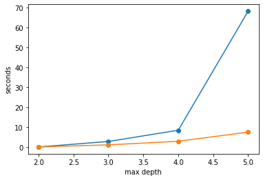

```python
import matplotlib.pyplot as plt
depths = [2, 3, 4, 5]
minimax = [0.187509, 2.922030, 8.571054, 68.246855]
alphabeta = [0.171883, 1.229612, 3.041824, 7.609780]

plt.plot(depths, minimax, '-o')
plt.plot(depths, alphabeta, '-o')
plt.xlabel('max depth')
plt.ylabel('seconds')
plt.show()
```